# What makes Jazz less popular?

Xin Gao UNI xg2298

9/15/2019

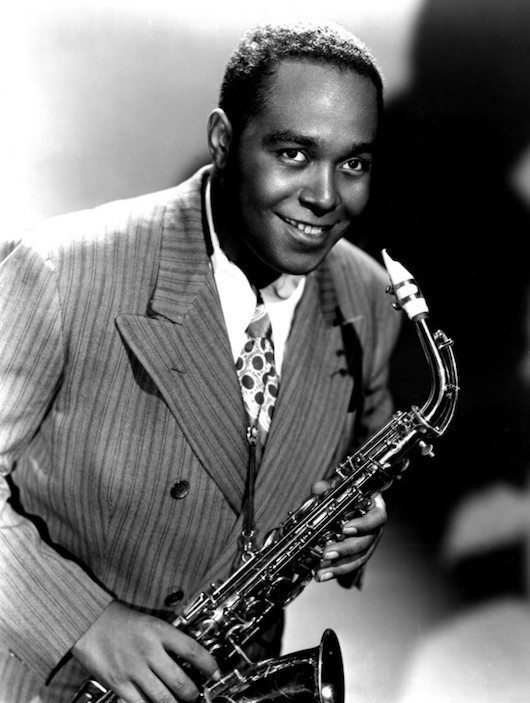

#### According to Nielsen’s report, jazz is the least listened-to music in the U.S.

#### This report is to figure out the possible reasons why jazz music become less attractive to people.

#### The whole dataset:“lyrics.csv” (Download) is a filtered corpus of 100,000+ song lyrics from MetroLyrics. Available features are song name, year, artist, genre, and lyrics.

```r
library(tidyverse)
library(tidytext)
library(plotly)
library(DT)
library(tm)
library(data.table)
library(scales)
library(wordcloud2)
library(gridExtra)
library(ngram)
library(shiny)
library(textdata)
library(cluster)
library(qdapTools)
library(lubridate)
```

First, I use the clean data processed by professor directly. (The file can be found in output file.) Then, I further clean the data by removing more stop words, such as I'll,didnt, youve, etc.

## Reason 1: The rise of other types of music, such as metal, hip-hop.

[interactive chart not shown]

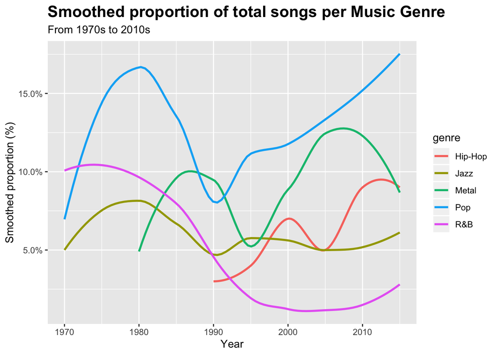

From the curve, we can tell that after 1980s, jazz music stay almost unchanged. At the same time, the other type of music start to occupy the market.

## Reason 2: Today’s music express deeper unhappiness than the songs of the past.

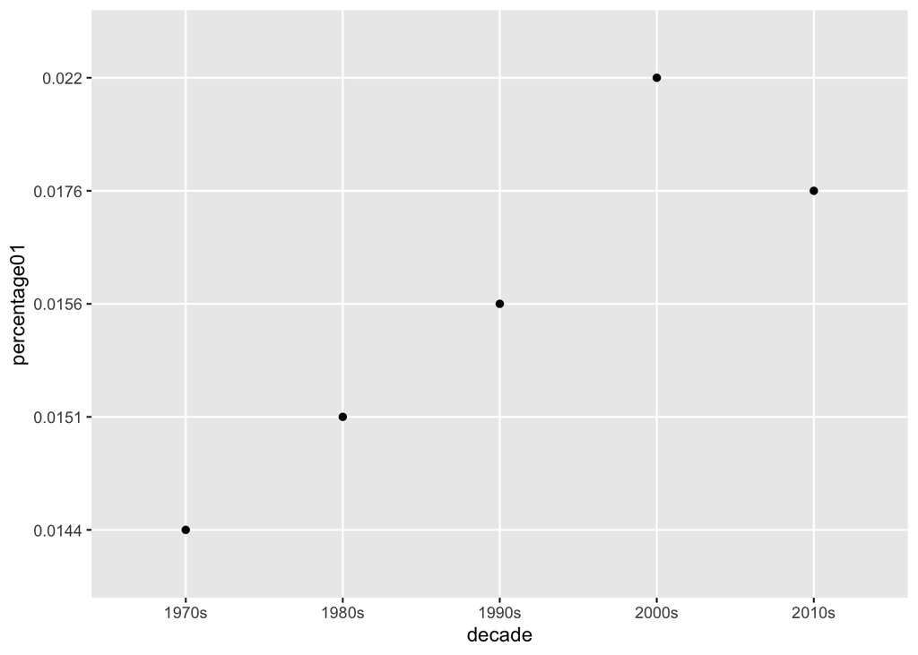

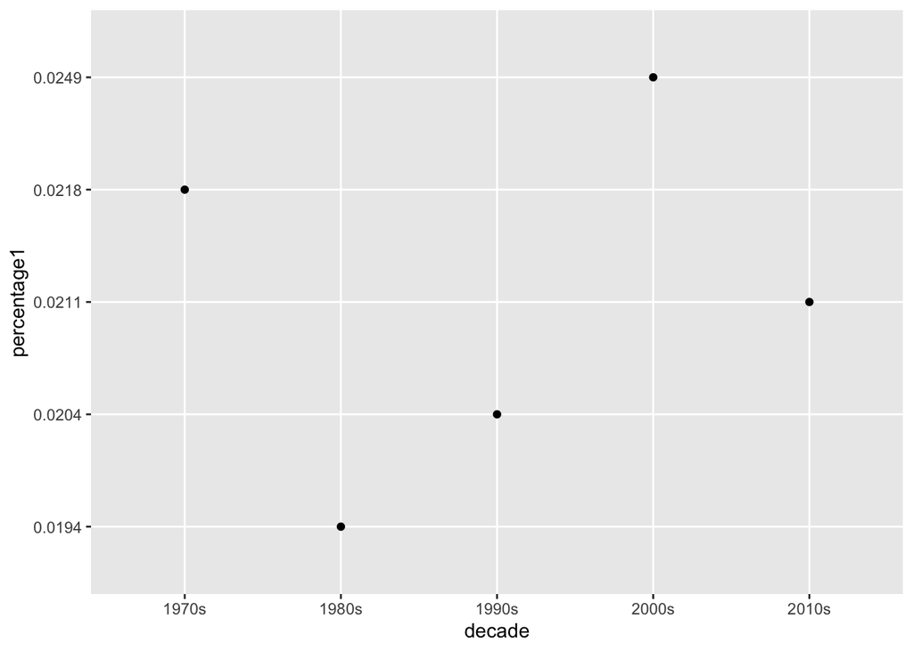

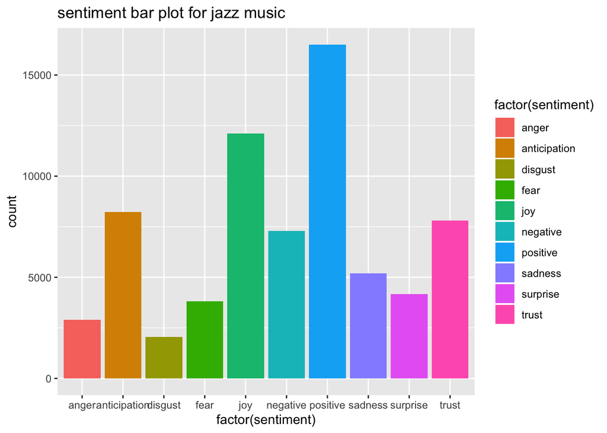

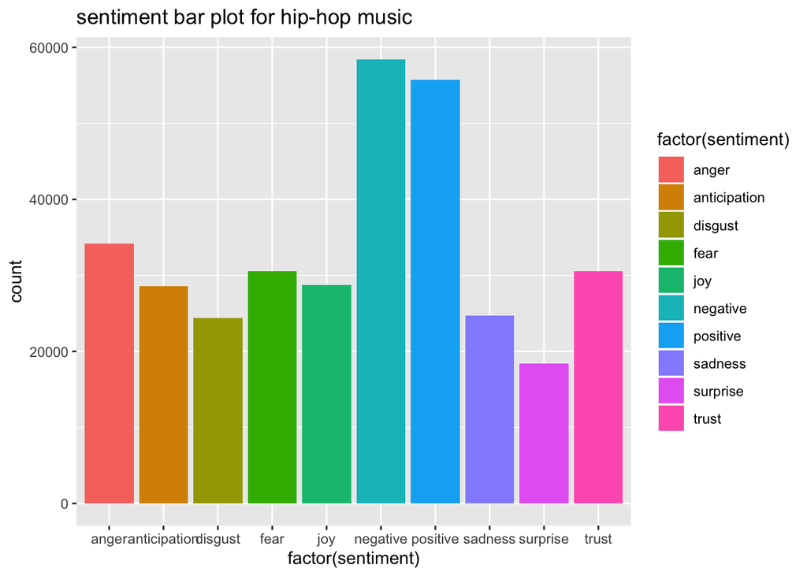

From the bar plot, I notice that the negative words appears more often on hip-hop music.

#### Lyrics become angrier, more fearful and less joyful may cause people spend less time on listening jazz music.

## Reason 3: Curious about the Fresh things.

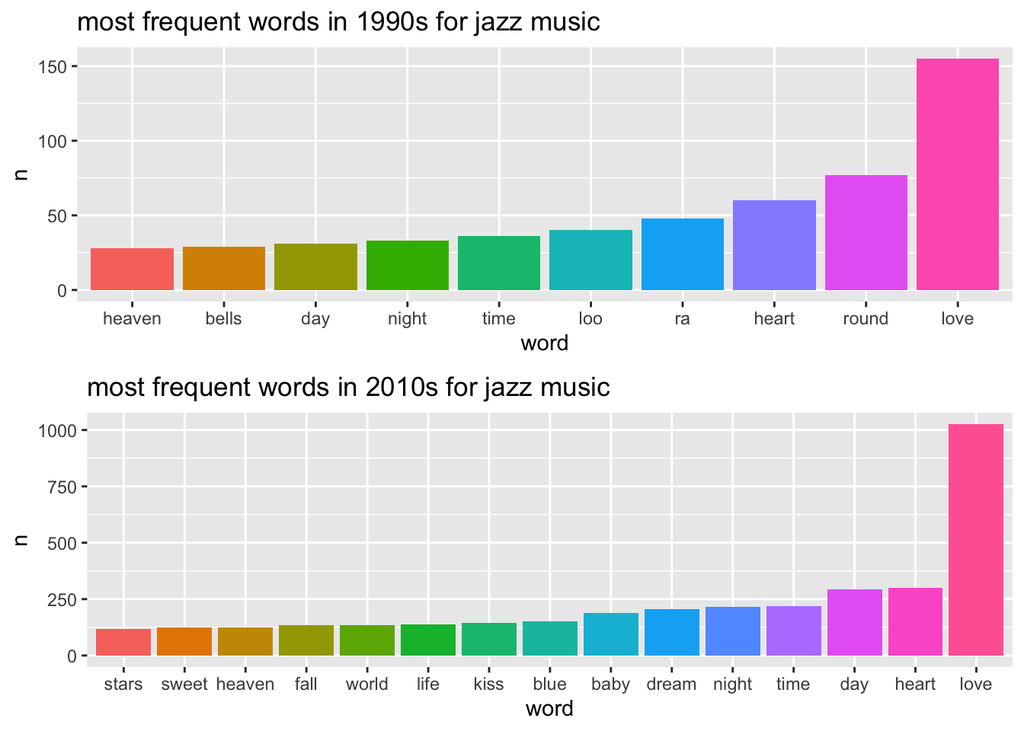

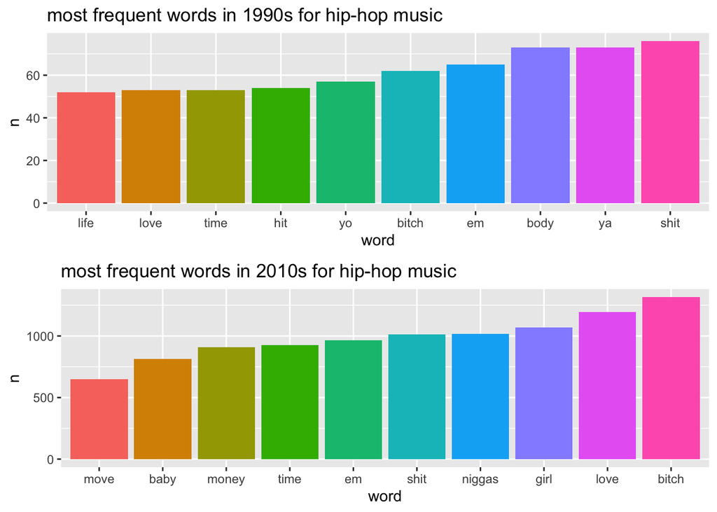

```
## integer(0)
```

```
## [1] 32
```

The development of technology also changes people’s listening style. I check the frequency of word 'technology’ appears in jazz music. It is 0. however, it appears on metal song lyrics 32 times.

#### Due to the curiousness of new stuff, people prefer other types of music instead of jazz– an old fashioned genre of music.

## Conclusions

1. The rise of other types of music which occupy the market.
2. Recently, people prefer to express negative feelings more. Jazz music is not their first choice to listen.
3. People like to try out the new things. Using slangs make them feel cool.